# ST-540 Assignment-2

Tilekbek Zhoroev

**Problem 1** $X_1$ and $X_2$ have joint PMF

| $x_1$ | $x_2$ | $Prob(X_1 = x_1;X_2 = x_2)$ |
| --- | --- | --- |
| 0 | 0 | 0.15 |
| 1 | 0 | 0.15 |
| 2 | 0 | 0.15 |
| 0 | 1 | 0.15 |
| 1 | 1 | 0.20 |
| 2 | 1 | 0.20 |

> 1. Compute the marginal distribution of $X_1$.
> 2. Compute the marginal distribution of $X_2$.
> 3. Compute the conditional distribution of $X_1|X_2$.
> 4. Compute the conditional distribution of $X_2|X_1$.
> 5. Are X1 and X2 independent? Justify your answer.

**Solution**

$P(X_1=0)=P(X_1=0, X_2=0)+P(X_1=0, X_2=1)=.15+.15=.3$

$P(X_1=1)=P(X_1=1, X_2=0)+P(X_1=1, X_2=1)=.15+.2=.35$

$P(X_2=0)=P(X_1=0, X_2=0)+P(X_1=1, X_2=0)+P(X_1=2, X_2=0)=.15+.15+.15=.45$

$P(X_2=1)=P(X_1=0, X_2=1)+P(X_1=1, X_2=1)+P(X_1=2, X_2=1)=.15+.2+.2=.55$

$P(X_1=0|X_2=0) =\frac{P(X_1=0, X_2=0)}{P(X_2=0)}=\frac{.15}{.45}=\frac{1}{3}$

$P(X_1=1|X_2=0) =\frac{P(X_1=1, X_2=0)}{P(X_2=0)}=\frac{.15}{.45}=\frac{1}{3}$  
$P(X_1=2|X_2=0) =\frac{P(X_1=2, X_2=0)}{P(X_2=0)}=\frac{.15}{.45}=\frac{1}{3}$

$P(X_1=0|X_2=1) =\frac{P(X_1=0, X_2=1)}{P(X_2=1)}=\frac{.15}{.55}=\frac{3}{11}$

$P(X_1=1|X_2=1) =\frac{P(X_1=1, X_2=1)}{P(X_2=1)}=\frac{.2}{.55}=\frac{4}{11}$

$P(X_1=2|X_2=1) =\frac{P(X_1=2, X_2=1)}{P(X_2=1)}=\frac{.2}{.55}=\frac{4}{11}$

$P(X_2=0|X_1=0) =\frac{P(X_1=0, X_2=0)}{P(X_1=0)}=\frac{.15}{.3}=\frac{1}{2}=.5$

$P(X_2=1|X_1=0) =\frac{P(X_1=0, X_2=1)}{P(X_1=0)}=\frac{.15}{.3}=\frac{1}{2}=.5$

$P(X_2=1|X_1=1) =\frac{P(X_1=1, X_2=1)}{P(X_1=1)}=\frac{.2}{.35}=\frac{4}{7}$

$P(X_2=0|X_1=2) =\frac{P(X_1=2, X_2=0)}{P(X_1=2)}=\frac{.15}{.35}=\frac{3}{7}$

$P(X_2=1|X_1=2) =\frac{P(X_1=2, X_2=1)}{P(X_1=2)}=\frac{.2}{.35}=\frac{4}{7}$

5. Since
   $$P(X_1=1, X_2=1)=0.2 \neq 0.1925=.35\times .55=P(X_1=1)\times P(X_2=1),$$
   $X_1$ and $X_2$ are dependent.

**Problem 2**

Assume $(X_1;X_2)$ have bivariate PDF
$$f(x_1; x_2)= \frac{1}{2\pi}(1+x_1^2+x_2^2)^{-\frac{3}{2}}$$

1. Plot the conditional distribution of $X_1|X_2 = x_2$ for $x_2 \in \{ -3,-2,-1,0,1,2,3\}$ (preferably on the same plot).
2. Do $X_1$ and $X_2$ appear to be correlated? Justify your answer.
3. Do $X_1$ and $X_2$ appear to be independent? Justify your answer

**Solution**

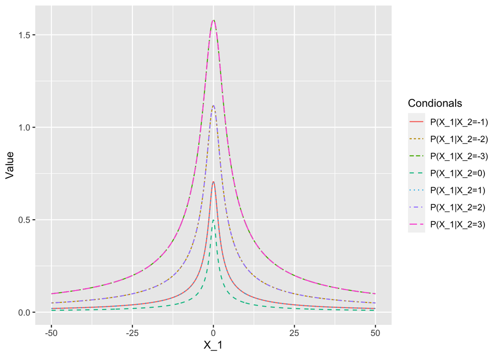

```r
x1<-seq(-50,50, length.out=500) # let us take x1 points between -50 and 50
x2<-c(-3,-2,-1,0,1,2,3) # x2 are given to us

con_dist<-sapply(x2,pdf_func) # apply function to all points in x2 by for loop
df<-data.frame(x1, con_dist) #define data frame
colnames(df)<-c("X_1","P(X_1|X_2=-3)","P(X_1|X_2=-2)","P(X_1|X_2=-1)","P(X_1|X_2=0)","P(X_1|X_2=1)","P(X_1|X_2=2)","P(X_1|X_2=3)")
df<- df%>%
pivot_longer(cols = "P(X_1|X_2=-3)":"P(X_1|X_2=3)", names_to = "Condionals", values_to = "Value") #I used this to create graphs in one figure

## use ggplot
ggplot(df, aes(x=X_1, y=Value, color=Condionals, linetype = Condionals  ))+
         geom_line(aes(color = Condionals))
```

3. There are not independent since $P(X_1|X_2)\neq P(X_1),$ if these were equal then all conditional distributions are should be same.

**Problem 3**

For this problem pretend we are dealing with a language with a six-word dictionary
$$\{\mbox{fun, sun, sit, sat, fan, for}\}.$$
An extensive study of literature written in this language reveals that all words are equally likely except that “for” is $\alpha$ times as likely as the other words. Further study reveals that:

1. Each keystroke is an error with probability $\theta$.
2. All letters are equally likely to produce errors.
3. Given that a letter is typed incorrectly it is equally likely to be any other letter.
4. Errors are independent across letters.

For example, the probability of correctly typing “fun” (or any other word) is $(1-\theta)^3$, the probability of typing “pun” or “fon” when intending to type is “fun” is $\theta(1-\theta)^2$, and the probability of typing “foo” or “nnn” when intending to type “fun” is $\theta^2(1-\theta)$. Use Bayes’ rule to develop a simple spell checker for this language. For each of the typed words “sun”, “the”, “foo”, give the probability that each word in the dictionary was the intended word. Perform this for the parameters below: (a) $\alpha = 2$ and $\theta= 0.1$ (b) $\alpha = 50$ and $\theta= 0.1$ (c) $\alpha = 2$ and $\theta= 0.95$ Comment on the changes you observe in these three cases

```r
likelihood = function(theta, v){
  theta^v*(1-theta)^(3-v)
}

alpha= 2; theta=.1
v_sun=c(1,0,2,2,2,3)
v_the=c(3,3,3,3,3,3)
v_foo=c(2,3,3,3,2,1)
data=data.frame(prior=round(ifelse(c("fun","sun","sit","sat","fan","for")=="for",alpha/(5+alpha),1/(5+alpha)),3))
row.names(data) = c("fun","sun","sit","sat","fan","for")
data<-data%>%
  mutate(sun_likelihood = round(likelihood(theta,v_sun),3))%>%
  mutate(sun_posterior = round(sun_likelihood*prior/sum(sun_likelihood*prior),3))%>%
  mutate(the_likelihood = round(likelihood(theta,v_the),3))%>%
  mutate(the_posterior= round(the_likelihood*prior/sum(the_likelihood*prior),3))%>%
  mutate(foo_likelihood = round(likelihood(theta,v_foo),3))%>%
  mutate(foo_posterior= round(foo_likelihood*prior/sum(foo_likelihood*prior),3))
data
```

|  | prior | sun_likelihood | sun_posterior | the_likelihood | the_posterior | foo_likelihood | foo_posterior |
| --- | --- | --- | --- | --- | --- | --- | --- |
| fun | 0.143 | 0.081 | 0.097 | 0.001 | 0.143 | 0.009 | 0.049 |
| sun | 0.143 | 0.729 | 0.869 | 0.001 | 0.143 | 0.001 | 0.005 |
| sit | 0.143 | 0.009 | 0.011 | 0.001 | 0.143 | 0.001 | 0.005 |
| sat | 0.143 | 0.009 | 0.011 | 0.001 | 0.143 | 0.001 | 0.005 |
| fan | 0.143 | 0.009 | 0.011 | 0.001 | 0.143 | 0.009 | 0.049 |
| for | 0.286 | 0.001 | 0.002 | 0.001 | 0.286 | 0.081 | 0.885 |

```r
likelihood = function(theta, v){
  theta^v*(1-theta)^(3-v)
}

alpha= 50; theta=.1
v_sun=c(1,0,2,2,2,3)
v_the=c(3,3,3,3,3,3)
v_foo=c(2,3,3,3,2,1)
data=data.frame(prior=round(ifelse(c("fun","sun","sit","sat","fan","for")=="for",alpha/(5+alpha),1/(5+alpha)),3))
row.names(data) = c("fun","sun","sit","sat","fan","for")
data<-data%>%
  mutate(sun_likelihood = round(likelihood(theta,v_sun),3))%>%
  mutate(sun_posterior = round(sun_likelihood*prior/sum(sun_likelihood*prior),3))%>%
  mutate(the_likelihood = round(likelihood(theta,v_the),3))%>%
  mutate(the_posterior= round(the_likelihood*prior/sum(the_likelihood*prior),3))%>%
  mutate(foo_likelihood = round(likelihood(theta,v_foo),3))%>%
  mutate(foo_posterior= round(foo_likelihood*prior/sum(foo_likelihood*prior),3))
data
```

|  | prior | sun_likelihood | sun_posterior | the_likelihood | the_posterior | foo_likelihood | foo_posterior |
| --- | --- | --- | --- | --- | --- | --- | --- |
| fun | 0.018 | 0.081 | 0.091 | 0.001 | 0.018 | 0.009 | 0.002 |
| sun | 0.018 | 0.729 | 0.821 | 0.001 | 0.018 | 0.001 | 0.000 |
| sit | 0.018 | 0.009 | 0.010 | 0.001 | 0.018 | 0.001 | 0.000 |
| sat | 0.018 | 0.009 | 0.010 | 0.001 | 0.018 | 0.001 | 0.000 |
| fan | 0.018 | 0.009 | 0.010 | 0.001 | 0.018 | 0.009 | 0.002 |
| for | 0.909 | 0.001 | 0.057 | 0.001 | 0.910 | 0.081 | 0.995 |

```r
likelihood = function(theta, v){
  theta^v*(1-theta)^(3-v)
}

alpha= 2; theta=.95
v_sun=c(1,0,2,2,2,3)
v_the=c(3,3,3,3,3,3)
v_foo=c(2,3,3,3,2,1)
data=data.frame(prior=round(ifelse(c("fun","sun","sit","sat","fan","for")=="for",alpha/(5+alpha),1/(5+alpha)),3))
row.names(data) = c("fun","sun","sit","sat","fan","for")
data<-data%>%
  mutate(sun_likelihood = round(likelihood(theta,v_sun),3))%>%
  mutate(sun_posterior = round(sun_likelihood*prior/sum(sun_likelihood*prior),3))%>%
  mutate(the_likelihood = round(likelihood(theta,v_the),3))%>%
  mutate(the_posterior= round(the_likelihood*prior/sum(the_likelihood*prior),3))%>%
  mutate(foo_likelihood = round(likelihood(theta,v_foo),3))%>%
  mutate(foo_posterior= round(foo_likelihood*prior/sum(foo_likelihood*prior),3))
data
```

|  | prior | sun_likelihood | sun_posterior | the_likelihood | the_posterior | foo_likelihood | foo_posterior |
| --- | --- | --- | --- | --- | --- | --- | --- |
| fun | 0.143 | 0.002 | 0.001 | 0.857 | 0.143 | 0.045 | 0.017 |
| sun | 0.143 | 0.000 | 0.000 | 0.857 | 0.143 | 0.857 | 0.322 |
| sit | 0.143 | 0.045 | 0.024 | 0.857 | 0.143 | 0.857 | 0.322 |
| sat | 0.143 | 0.045 | 0.024 | 0.857 | 0.143 | 0.857 | 0.322 |
| fan | 0.143 | 0.045 | 0.024 | 0.857 | 0.143 | 0.045 | 0.017 |
| for | 0.286 | 0.857 | 0.926 | 0.857 | 0.286 | 0.002 | 0.002 |